# Analysis of severe weather events on public health and economic consequences across United States

Maverix13

September 21, 2015

## Synopsis

This report explores the NOAA Storm Database and answer some basic questions about severe weather events. The analysis covers:

- Across United States, events that are most harmful to public health.
- Across United States, events that have greatest economic consequences.

Results, covered later in the document, shows that 50% of the fatalities are caused by Extreme Temperature and Convection related weather events while combined with Flood and Wind accounts for about 80% of fatalities. Similarly, Convection and Extreme Temperatures cause about 60% of injuries, which combined with combined with Flood and Wind causes over 80% injuries. Economic impact of weather related activities is mostly caused by Flood and Cyclone resulting in over $250 billion. Property damage accounts for over 90% of the economic impact.

## Data Processing

Data is downloaded, if required. Code checks if data already exists. Data is then loaded into R. Note that a zip file is directly read using read.csv. There is no need to unzip it as read.csv will handle it.

```r
#install.packages("devtools")
#devtools::install_github("renkun-ken/formattable")
library(knitr)
library(dplyr)
library(ggplot2)
library(formattable)
library(reshape2)
require(gridExtra)
```

```r
if(!file.exists("data")){
  dir.create("data")
}
if(!file.exists("data/stormData.csv.bz2")) {
  download.file("https://d396qusza40orc.cloudfront.net/repdata%2Fdata%2FStormData.csv.bz2", "data/stormData.csv.bz2", method = "curl")

}

stormData <- read.csv("data/stormData.csv.bz2")
dim(stormData)
```

```
## [1] 902297     37
```

```r
head(stormData[,2:28])
```

```
##             BGN_DATE BGN_TIME TIME_ZONE COUNTY COUNTYNAME STATE  EVTYPE
## 1  4/18/1950 0:00:00     0130       CST     97     MOBILE    AL TORNADO
## 2  4/18/1950 0:00:00     0145       CST      3    BALDWIN    AL TORNADO
## 3  2/20/1951 0:00:00     1600       CST     57    FAYETTE    AL TORNADO
## 4   6/8/1951 0:00:00     0900       CST     89    MADISON    AL TORNADO
## 5 11/15/1951 0:00:00     1500       CST     43    CULLMAN    AL TORNADO
## 6 11/15/1951 0:00:00     2000       CST     77 LAUDERDALE    AL TORNADO
##   BGN_RANGE BGN_AZI BGN_LOCATI END_DATE END_TIME COUNTY_END COUNTYENDN
## 1         0                                               0         NA
## 2         0                                               0         NA
## 3         0                                               0         NA
## 4         0                                               0         NA
## 5         0                                               0         NA
## 6         0                                               0         NA
##   END_RANGE END_AZI END_LOCATI LENGTH WIDTH F MAG FATALITIES INJURIES
## 1         0                      14.0   100 3   0          0       15
## 2         0                       2.0   150 2   0          0        0
## 3         0                       0.1   123 2   0          0        2
## 4         0                       0.0   100 2   0          0        2
## 5         0                       0.0   150 2   0          0        2
## 6         0                       1.5   177 2   0          0        6
##   PROPDMG PROPDMGEXP CROPDMG CROPDMGEXP
## 1    25.0          K       0
## 2     2.5          K       0
## 3    25.0          K       0
## 4     2.5          K       0
## 5     2.5          K       0
## 6     2.5          K       0
```

### Preprocessing Data

As the histogram below shows, in the earlier years of the database there are generally fewer events recorded, most likely due to a lack of good records.

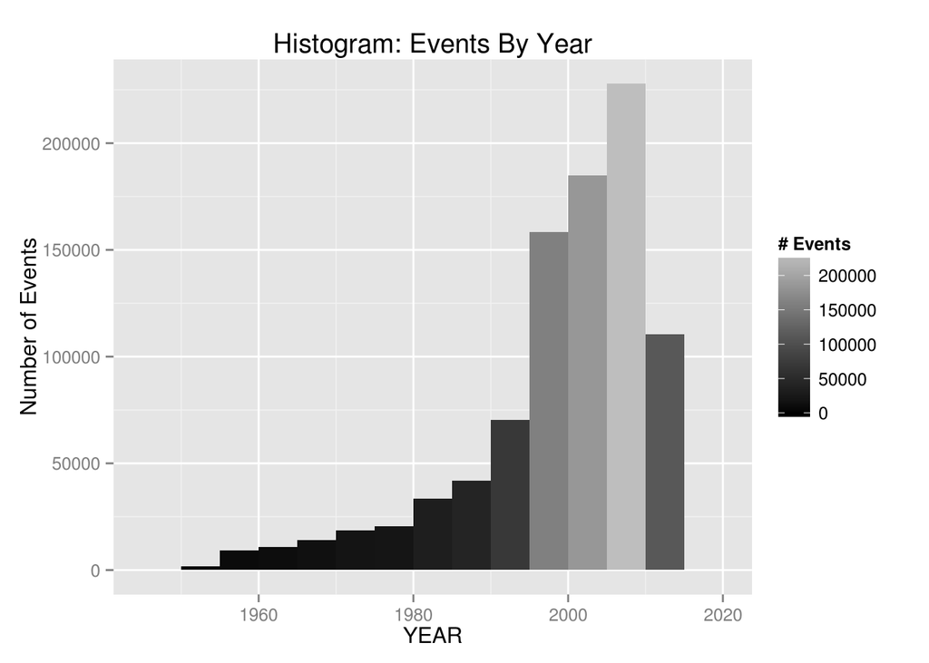

```r
stormData <- mutate(stormData, YEAR = as.numeric(format(as.Date(BGN_DATE, format = "%m/%d/%Y %H:%M:%S"), "%Y")))
g <- ggplot(stormData, aes(YEAR, fill = ..count.., removePanelGrid=TRUE,removePanelBorder=TRUE)) +
  geom_histogram(binwidth=5) +
  ylab("Number of Events") +
  scale_fill_gradient("# Events", low = "black", high = "gray") +
  ggtitle("Histogram: Events By Year")
print(g)
```

Hence for this report, data after 1996 is considered for analysis.

```r
stormData <- stormData[stormData$YEAR >= 1996,]
dim(stormData)
```

```
## [1] 653530     38
```

Following columns are of relevance for the current analysis

| Column Name | Description |
| --- | --- |
| EVTYPE | Type of storm event. Take note that similar storm events can be listed using different wording e.g. “coastal flood” and “coastal flooding.” Take note of this if you want to run a query grouping by eve… |
| FATALITIES | Number directly killed |
| INJURIES | Number directly injured |
| PROPDMG | Property damage in whole numbers and hundredths |
| PROPDMGEXP | A multiplier where Hundred (H), Thousand (K), Million (M), Billion (B) |
| CROPDMG | Crop damage in whole numbers and hundredths |
| CROPDMGEXP | A multiplier where Hundred (H), Thousand (K), Million (M), Billion (B) |

This above table is constructed based on information from http://ire.org/nicar/database-library/databases/storm-events/

Further reduction of stormData based on columns and row values

```r
## Just keeping relevant columns
relevantColumns <- c("EVTYPE", "FATALITIES", "INJURIES", "PROPDMG", "PROPDMGEXP", "CROPDMG", "CROPDMGEXP")
stormData <- stormData[,relevantColumns]
## Keep rows having any data
stormData <- subset(stormData, FATALITIES > 0 | INJURIES > 0 | PROPDMG > 0 | CROPDMG > 0)
```

#### Mapping of Events to Group

Many events can be grouped together based on similarity. The categorization for this report is based on NOAA 2009 Annual Summaries (http://www.ncdc.noaa.gov/oa/climate/sd/annsum2009.pdf).

```r
stormData$EVGROUP <- "Others"
stormData[grepl("tornado|thunderstorm|hail|funnel|tstm|lig(.*?)ing",
                stormData$EVTYPE, ignore.case = TRUE), "EVGROUP"] <- "Convection"
stormData[grepl("temperature|cold|cool|heat|hot|fire|dry|warm|wet|freez",
                stormData$EVTYPE, ignore.case = TRUE), "EVGROUP"] <- "Extreme Temperature"
stormData[grepl("flood|rain|mud(.*?)slid",
                stormData$EVTYPE, ignore.case = TRUE), "EVGROUP"] <- "Flood"
stormData[grepl("marine|sea|tide|coast|tsunami|current|surf|wave",
                stormData$EVTYPE, ignore.case = TRUE), "EVGROUP"] <- "Marine"
stormData[grepl("tropic|cyclone|hurricane",
                stormData$EVTYPE, ignore.case = TRUE), "EVGROUP"] <- "Cyclone"
stormData[grepl("avalanche|snow|blizzard|winter|wintry|ice",
                stormData$EVTYPE, ignore.case = TRUE), "EVGROUP"] <- "Winter"
stormData[grepl("wind|dust",
                stormData$EVTYPE, ignore.case = TRUE), "EVGROUP"] <- "Wind"

stormData$EVGROUP <- as.factor(stormData$EVGROUP)
```

### Analysis on public health

Analysis of fatalities and injuries caused by a given storm event group.

```r
pubHealthData <- stormData %>%
  group_by(EVGROUP) %>%
  summarize(fatalities = sum(FATALITIES), injuries = sum(INJURIES))
kable(pubHealthData)
```

| EVGROUP | fatalities | injuries |
| --- | --- | --- |
| Convection | 2170 | 25533 |
| Cyclone | 182 | 1661 |
| Extreme Temperature | 2267 | 9202 |
| Flood | 1404 | 8670 |
| Marine | 751 | 989 |
| Others | 160 | 1302 |
| Wind | 1034 | 7127 |
| Winter | 764 | 3491 |

### Analysis on Economic Impact

Analysis of property and crop damage caused by a given event group.

```r
unique(stormData$PROPDMGEXP)
```

```
## [1] K   M B
## Levels:  - ? + 0 1 2 3 4 5 6 7 8 B h H K m M
```

```r
unique(stormData$CROPDMGEXP)
```

```
## [1] K   M B
## Levels:  ? 0 2 B k K m M
```

Unique values for both property and crop damage exponents is [‘K’, ‘M’, ‘B’]. These values are mulitpliers as mentioned above in column descriptions.

```r
economicData <- stormData %>%
  mutate(PROPDMGVAL = PROPDMG * (
    ifelse(PROPDMGEXP == "K", 1000,
           ifelse(PROPDMGEXP == "M", 1000000,
                  ifelse(PROPDMGEXP == "B", 1000000000,
                         1  )))))  %>%
  mutate(CROPDMGVAL = CROPDMG * (
    ifelse(CROPDMGEXP == "K", 1000,
           ifelse(CROPDMGEXP == "M", 1000000,
                  ifelse(CROPDMGEXP == "B", 1000000000,
                         1  ))))) %>%
  mutate(TOTALDMG = PROPDMGVAL + CROPDMGVAL) %>%
  group_by(EVGROUP) %>%
  summarize(propertyDamage = sum(PROPDMGVAL), cropDamage = sum(CROPDMGVAL), totalDamage = sum(TOTALDMG)) %>%
  arrange(desc(totalDamage))
economicData$EVGROUP <- factor(economicData$EVGROUP, levels=economicData$EVGROUP)
formattable(economicData, list(
  propertyDamage=currency,
  cropDamage=currency,
  totalDamage=currency
))
```

| EVGROUP | propertyDamage | cropDamage | totalDamage |
| --- | --- | --- | --- |
| Flood | $159,904,859,000.00 | $7,067,994,900.00 | $166,972,853,900.00 |
| Cyclone | $88,762,871,560.00 | $6,026,993,800.00 | $94,789,865,360.00 |
| Others | $45,253,732,050.00 | $13,439,935,500.00 | $58,693,667,550.00 |
| Convection | $39,955,370,310.00 | $2,787,145,900.00 | $42,742,516,210.00 |
| Wind | $13,369,105,350.00 | $1,736,767,400.00 | $15,105,872,750.00 |
| Extreme Temperature | $7,812,842,200.00 | $3,530,582,630.00 | $11,343,424,830.00 |
| Winter | $6,413,677,850.00 | $120,786,100.00 | $6,534,463,950.00 |
| Marine | $5,295,157,060.00 | $42,522,500.00 | $5,337,679,560.00 |

## Results

### Impact on public health

```r
fData <- pubHealthData %>%
  arrange(desc(fatalities)) %>%
  select(EVGROUP, fatalities) %>%
  mutate(
    cumulativeSum = cumsum(fatalities),
    cumPercent = cumulativeSum/sum(fatalities)
  )
formattable(fData, list(
  cumPercent = percent
))
```

| EVGROUP | fatalities | cumulativeSum | cumPercent |
| --- | --- | --- | --- |
| Extreme Temperature | 2267 | 2267 | 25.96% |
| Convection | 2170 | 4437 | 50.81% |
| Flood | 1404 | 5841 | 66.89% |
| Wind | 1034 | 6875 | 78.73% |
| Winter | 764 | 7639 | 87.48% |
| Marine | 751 | 8390 | 96.08% |
| Cyclone | 182 | 8572 | 98.17% |
| Others | 160 | 8732 | 100.00% |

```r
iData <- pubHealthData %>%
  arrange(desc(injuries)) %>%
  select(EVGROUP, injuries) %>%
  mutate(
    cumulativeSum = cumsum(injuries),
    cumPercent = cumulativeSum/sum(injuries)
  )
formattable(iData, list(
  cumPercent = percent
))
```

| EVGROUP | injuries | cumulativeSum | cumPercent |
| --- | --- | --- | --- |
| Convection | 25533 | 25533 | 44.04% |
| Extreme Temperature | 9202 | 34735 | 59.91% |
| Flood | 8670 | 43405 | 74.87% |
| Wind | 7127 | 50532 | 87.16% |
| Winter | 3491 | 54023 | 93.18% |
| Cyclone | 1661 | 55684 | 96.05% |
| Others | 1302 | 56986 | 98.29% |
| Marine | 989 | 57975 | 100.00% |

As with fatalities, injuries are also mostly caused by Convection, Extreme Temperature, Flood and Wind resulting in over 50,000 injuries.

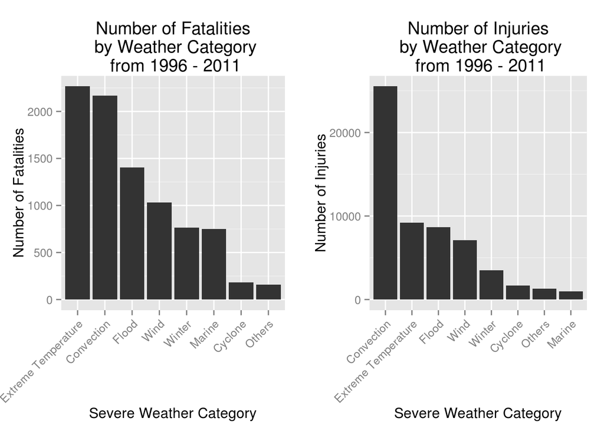

```r
fPlot <- ggplot(fData, aes(x=reorder(EVGROUP, desc(fatalities)))) +
  geom_bar(aes(y=fatalities), stat = "identity") +
  theme(axis.text.x = element_text(angle = 45, hjust = 1)) +
  xlab("Severe Weather Category") +
  scale_y_continuous("Number of Fatalities") +
  ggtitle("Number of Fatalities\n by Weather Category\n from 1996 - 2011")
iPlot <- ggplot(iData, aes(x=reorder(EVGROUP, desc(injuries)))) +
  geom_bar(aes(y=injuries), stat = "identity") +
  theme(axis.text.x = element_text(angle = 45, hjust = 1)) +
  xlab("Severe Weather Category") +
  scale_y_continuous("Number of Injuries") +
  ggtitle("Number of Injuries\n by Weather Category\n from 1996 - 2011")
grid.arrange(fPlot, iPlot, ncol = 2)
```

Based on the graphs above, we see that there are lot more injuries compared to fatalities but the top 2 weather event are Extreme Tmperature and Convection.

### Impact on Economy

```r
pData <- economicData %>%
  arrange(desc(propertyDamage)) %>%
  select(EVGROUP, propertyDamage) %>%
  mutate(
    cumulativeSum = cumsum(propertyDamage),
    cumPercent = cumulativeSum/sum(propertyDamage)
  )
formattable(pData, list(
  propertyDamage=currency,
  cumPercent = percent
))
```

| EVGROUP | propertyDamage | cumulativeSum | cumPercent |
| --- | --- | --- | --- |
| Flood | $159,904,859,000.00 | 159904859000 | 43.60% |
| Cyclone | $88,762,871,560.00 | 248667730560 | 67.80% |
| Others | $45,253,732,050.00 | 293921462610 | 80.14% |
| Convection | $39,955,370,310.00 | 333876832920 | 91.03% |
| Wind | $13,369,105,350.00 | 347245938270 | 94.68% |
| Extreme Temperature | $7,812,842,200.00 | 355058780470 | 96.81% |
| Winter | $6,413,677,850.00 | 361472458320 | 98.56% |
| Marine | $5,295,157,060.00 | 366767615380 | 100.00% |

```r
cData <- economicData %>%
  arrange(desc(cropDamage)) %>%
  select(EVGROUP, cropDamage) %>%
  mutate(
    cumulativeSum = cumsum(cropDamage),
    cumPercent = cumulativeSum/sum(cropDamage)
  )
formattable(cData, list(
  cropDamage=currency,
  cumPercent = percent
))
```

| EVGROUP | cropDamage | cumulativeSum | cumPercent |
| --- | --- | --- | --- |
| Others | $13,439,935,500.00 | 13439935500 | 38.67% |
| Flood | $7,067,994,900.00 | 20507930400 | 59.01% |
| Cyclone | $6,026,993,800.00 | 26534924200 | 76.35% |
| Extreme Temperature | $3,530,582,630.00 | 30065506830 | 86.51% |
| Convection | $2,787,145,900.00 | 32852652730 | 94.53% |
| Wind | $1,736,767,400.00 | 34589420130 | 99.53% |
| Winter | $120,786,100.00 | 34710206230 | 99.88% |
| Marine | $42,522,500.00 | 34752728730 | 100.00% |

Comparing crop damage to property damage shows that crop damage does not have as significant economic impact as property damage. Crop damage totaled close to $34 billion across all weather events. Hence the chart below takes total property damage into account.

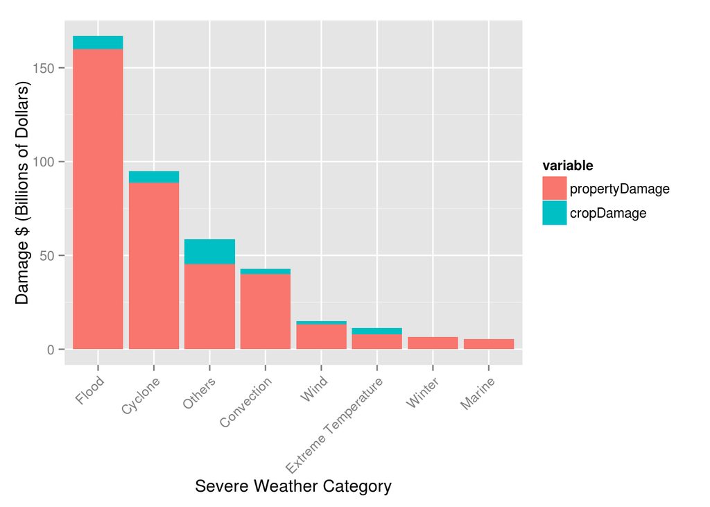

```r
meltData <- melt(economicData[,c('EVGROUP','propertyDamage','cropDamage')], id.var="EVGROUP")
ePlot <- ggplot(meltData, aes(x = EVGROUP, y = value/1000000000, fill = variable)) +
  geom_bar(stat = "identity") +
  xlab("Severe Weather Category") +
  scale_y_continuous("Damage $ (Billions of Dollars)") +
  theme(axis.text.x = element_text(angle = 45, hjust = 1))
print(ePlot)
```

Majority of economic impact is attributed to property damage caused by Flood and Cyclone.